# predictive_maintainence

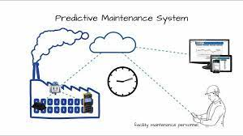

**This is an project related to time series forecasting for predictive maintence.** *This project uses dataset that are available on Kaggle.

About Dataset Context This an example data source which can be used for Predictive Maintenance Model Building. It consists of the following data:

Machine conditions and usage: The operating conditions of a machine e.g. data collected from sensors. Failure history: The failure history of a machine or component within the machine. Maintenance history: The repair history of a machine, e.g. error codes, previous maintenance activities or component replacements. Machine features: The features of a machine, e.g. engine size, make and model, location. Details Telemetry Time Series Data (PdM_telemetry.csv): It consists of hourly average of voltage, rotation, pressure, vibration collected from 100 machines for the year 2015.

Error (PdM_errors.csv): These are errors encountered by the machines while in operating condition. Since, these errors don't shut down the machines, these are not considered as failures. The error date and times are rounded to the closest hour since the telemetry data is collected at an hourly rate.

Maintenance (PdM_maint.csv): If a component of a machine is replaced, that is captured as a record in this table. Components are replaced under two situations: 1. During the regular scheduled visit, the technician replaced it (Proactive Maintenance) 2. A component breaks down and then the technician does an unscheduled maintenance to replace the component (Reactive Maintenance). This is considered as a failure and corresponding data is captured under Failures. Maintenance data has both 2014 and 2015 records. This data is rounded to the closest hour since the telemetry data is collected at an hourly rate.

Failures (PdM_failures.csv): Each record represents replacement of a component due to failure. This data is a subset of Maintenance data. This data is rounded to the closest hour since the telemetry data is collected at an hourly rate.

Metadata of Machines (PdM_Machines.csv): Model type & age of the Machines.

[download dataset](https://www.kaggle.com/code/jegun19/predictive-maintenance-time-series-forecasting/)

```python
##load data using pandas
import os
import pandas as pd
working_path = "/content/drive/MyDrive/data/"
df_tele = pd.read_csv(working_path+"PdM_telemetry.csv")
df_fail = pd.read_csv(working_path+"PdM_failures.csv")
df_err = pd.read_csv(working_path+"PdM_errors.csv")
df_maint = pd.read_csv(working_path+"PdM_maint.csv")
```

|  | datetime | machineID | failure |
| --- | --- | --- | --- |
| 0 | 2015-01-05 06:00:00 | 1 | comp4 |
| 1 | 2015-03-06 06:00:00 | 1 | comp1 |
| 2 | 2015-04-20 06:00:00 | 1 | comp2 |
| 3 | 2015-06-19 06:00:00 | 1 | comp4 |
| 4 | 2015-09-02 06:00:00 | 1 | comp4 |

Categorical distributions

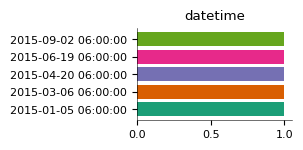

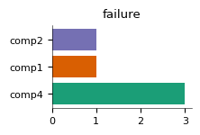

2-d categorical distributions

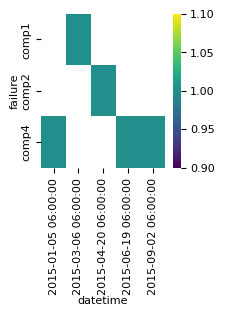

Time series

[figure not shown]

[figure not shown]

[figure not shown]

[figure not shown]

```python
#printing the top 5 row
df_fail.head(n=5)
```

|  | datetime | machineID | volt | rotate | pressure | vibration |
| --- | --- | --- | --- | --- | --- | --- |
| 0 | 2015-01-01 06:00:00 | 11 | 164.039259 | 389.699577 | 113.619975 | 29.775109 |
| 1 | 2015-01-01 07:00:00 | 11 | 180.325510 | 409.788550 | 97.506203 | 40.512160 |
| 2 | 2015-01-01 08:00:00 | 11 | 146.917119 | 420.626012 | 97.087205 | 33.420937 |
| 3 | 2015-01-01 09:00:00 | 11 | 164.895416 | 426.409611 | 86.494413 | 40.263365 |
| 4 | 2015-01-01 10:00:00 | 11 | 174.330072 | 471.774231 | 109.277816 | 39.931749 |

Categorical distributions

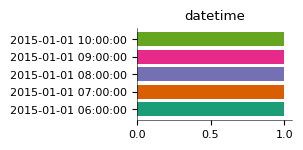

2-d distributions

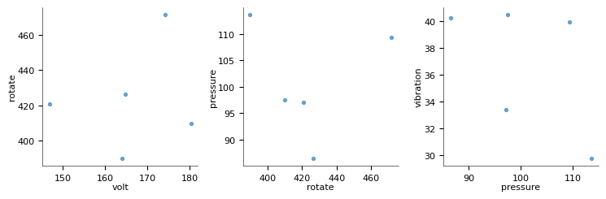

Faceted distributions

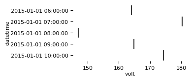

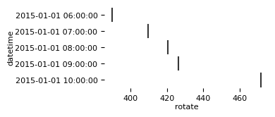

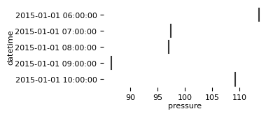

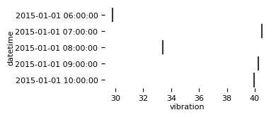

Time series

[figure not shown]

[figure not shown]

[figure not shown]

[figure not shown]

```python
df_sel = df_tele.loc[df_tele['machineID']==11].reset_index(drop=True)
df_sel.head(n=5)
```

|  | datetime | machineID | failure |
| --- | --- | --- | --- |
| 58 | 2015-01-20 06:00:00 | 11 | comp2 |
| 59 | 2015-02-19 06:00:00 | 11 | comp3 |
| 60 | 2015-04-20 06:00:00 | 11 | comp2 |
| 61 | 2015-04-20 06:00:00 | 11 | comp3 |
| 62 | 2015-10-02 06:00:00 | 11 | comp3 |
| 63 | 2015-12-16 06:00:00 | 11 | comp3 |

Categorical distributions

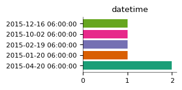

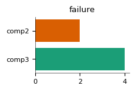

2-d categorical distributions

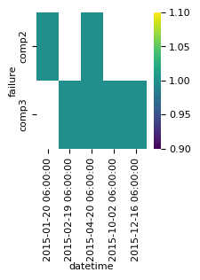

Time series

[figure not shown]

[figure not shown]

[figure not shown]

[figure not shown]

```python
#check failure record of same machine whose ID is 11
sel_fail = df_fail.loc[df_fail['machineID']==11]
pd.DataFrame(sel_fail)
```